# 260 Analysis

James Wen

# Load Data and Create Variables

```r
library(tidyverse)
library(lubridate)
library(splitstackshape)
library(janitor)
library(caret)
library(ROSE)
library(pROC)
library(PRROC)
# setwd("~/Desktop/21F/BST_260/Project/Data")
set.seed(260)

# bikedata <- list.files(pattern = "*-citibike-tripdata.csv") %>%
#   map_df(~read_csv(.))
setwd("~/Desktop/21F/BST_260/Project")
#bikedata <- readRDS("data.RDS")

# bikedata_1 <- sample_frac(bikedata, 0.01)

# write.csv(bikedata_1, "sampled_data.csv")

# bikedata_1 <- read.csv("bikedata_sampled_1percent.csv")

# load("bike_join.RData")
#sample_size <- nrow(bike_join) %/% 100
#out <- stratified(bike_join, c("start_time"), sample_size)

#bikedata_1 <- sample_frac(bike_join, 0.01)

# write.csv(bikedata_1, "geo_sample.csv")

bikedata_1 <- read.csv("geo_sample.csv")




# geo <- bikedata_1 %>%
#   select(suburb, major_city) %>%
#   mutate(suburb_major_ciy = paste(suburb,major_city, sep = ","))


bikedata_2 <- bikedata_1 %>%
  mutate(day_of_week = wday(start_time, label = TRUE, abbr = TRUE)) %>%
  # 1 = weekend, 0 = weekday
  mutate(day_type = ifelse(day_of_week %in% c("Sat", "Sun"), 1,0)) %>%
  #mutate(age = 2020 - birth_year) %>%
  #mutate(trip_date = ymd(trip_date)) %>%
  mutate(month = month(start_time)) %>%
  mutate(age_cat = ifelse(age < 20, "Under 20",
                          ifelse(age < 30, "20s",
                                 ifelse(age < 40, "30s",
                                        ifelse(age < 50, "40s",
                                               ifelse( age < 60, "50s",
                                                       ifelse(age < 70, "60s",
                                                              ifelse(age < 80, "70s", "80+")))))))) %>%
  mutate(gender = as.factor(gender)) %>%
  mutate(user_type = factor(user_type, levels = c("Customer", "Subscriber"))) %>%
  mutate(season = ifelse(month %in% c(3,4,5), "Spring",
                         ifelse(month %in% c(6,7,8), "Summer",
                                ifelse(month %in% c(9,10,11), "Fall", "Winter")))) %>%
  mutate(winter = ifelse(season == "Winter", 1, 0))
```

# Model Building

```r
bikedata_3 <- bikedata_2 %>%
  mutate(user_type = ifelse(user_type == "Subscriber", 1, 0 )) %>%
  mutate(month = as.factor(month),
         suburb = as.factor(suburb),
         winter = as.factor(winter)) %>%
  select(user_type, gender, day_type, suburb, age, winter) %>%
  na.omit()

bikedata_3$suburb <- relevel(bikedata_3$suburb , ref= "Manhattan")

set.seed(260)
x <- stratified(bikedata_3, "user_type", 0.8, keep.rownames = TRUE)
train_set <- x %>%
  dplyr::select(-rn)
train_index <- as.numeric(x$rn)
test_set <- bikedata_3[-train_index,]
dim(train_set)
```

```
## [1] 156052      6
```

```r
dim(test_set)
```

```
## [1] 39016     6
```

# Models based on available variables

```r
model <- glm(user_type ~ gender + day_type + suburb + age + winter , data = bikedata_3, family = binomial)

summary(model)
```

```
##
## Call:
## glm(formula = user_type ~ gender + day_type + suburb + age +
##     winter, family = binomial, data = bikedata_3)
##
## Deviance Residuals:
##     Min       1Q   Median       3Q      Max
## -3.8829   0.1582   0.4084   0.6344   3.0317
##
## Coefficients:
##                   Estimate Std. Error  z value Pr(>|z|)
## (Intercept)     -5.1548060  0.0456795 -112.847   <2e-16 ***
## gender1          4.7850644  0.0271488  176.253   <2e-16 ***
## gender2          4.4880788  0.0282706  158.754   <2e-16 ***
## day_type        -0.5106837  0.0136656  -37.370   <2e-16 ***
## suburbBrooklyn  -0.1719581  0.0158630  -10.840   <2e-16 ***
## suburbQueens    -0.0912217  0.0321135   -2.841   0.0045 **
## suburbThe Bronx -0.8290709  0.0631923  -13.120   <2e-16 ***
## age              0.0658977  0.0007858   83.857   <2e-16 ***
## winter1          1.0329027  0.0225877   45.728   <2e-16 ***
## ---
## Signif. codes:  0 '***' 0.001 '**' 0.01 '*' 0.05 '.' 0.1 ' ' 1
##
## (Dispersion parameter for binomial family taken to be 1)
##
##     Null deviance: 211489  on 195064  degrees of freedom
## Residual deviance: 149682  on 195056  degrees of freedom
## AIC: 149700
##
## Number of Fisher Scoring iterations: 5
```

```r
predicted <- predict(model, newdata = test_set, type = "response" )

classification <- ifelse(predicted > 0.5, 1, 0)
confusionMatrix(data = as.factor(classification), reference = as.factor(test_set$user_type), positive = '1')
```

```
## Confusion Matrix and Statistics
##
##           Reference
## Prediction     0     1
##          0  3783   530
##          1  5307 29396
##
##                Accuracy : 0.8504
##                  95% CI : (0.8468, 0.8539)
##     No Information Rate : 0.767
##     P-Value [Acc > NIR] : < 2.2e-16
##
##                   Kappa : 0.4877
##
##  Mcnemar's Test P-Value : < 2.2e-16
##
##             Sensitivity : 0.9823
##             Specificity : 0.4162
##          Pos Pred Value : 0.8471
##          Neg Pred Value : 0.8771
##              Prevalence : 0.7670
##          Detection Rate : 0.7534
##    Detection Prevalence : 0.8895
##       Balanced Accuracy : 0.6992
##
##        'Positive' Class : 1
##
```

As the output shows, the model has good accuracy and sensitivity but very low specificity. This is due to how unbalanced our data is. An overwhelming majority of trips are done by people designated as a `Subscriber`.

To account for this, we are going to over-sample `Customer` class and re-run our model to see if we can achieve more equity between specificity and sensitivity.

```r
set.seed(260)
data_balanced_over <- ovun.sample(user_type ~ ., data = train_set, method = "both",N = 239590)$data
table(train_set$user_type)
```

```
##
##      0      1
##  36258 119794
```

```r
table(data_balanced_over$user_type)
```

```
##
##      0      1
## 119799 119791
```

```r
model_adj <- glm(user_type ~ gender + day_type + suburb + age + winter , data = data_balanced_over, family = binomial)

summary(model_adj)
```

```
##
## Call:
## glm(formula = user_type ~ gender + day_type + suburb + age +
##     winter, family = binomial, data = data_balanced_over)
##
## Deviance Residuals:
##     Min       1Q   Median       3Q      Max
## -3.6154  -0.9575  -0.0699   0.8760   3.4243
##
## Coefficients:
##                   Estimate Std. Error z value Pr(>|z|)
## (Intercept)     -6.6038413  0.0366940 -179.97  < 2e-16 ***
## gender1          4.8973478  0.0253399  193.27  < 2e-16 ***
## gender2          4.5928554  0.0260751  176.14  < 2e-16 ***
## day_type        -0.5041324  0.0105537  -47.77  < 2e-16 ***
## suburbBrooklyn  -0.1451302  0.0122401  -11.86  < 2e-16 ***
## suburbQueens    -0.0909511  0.0248484   -3.66 0.000252 ***
## suburbThe Bronx -0.7492460  0.0527040  -14.22  < 2e-16 ***
## age              0.0704696  0.0005613  125.55  < 2e-16 ***
## winter1          1.0164949  0.0160215   63.45  < 2e-16 ***
## ---
## Signif. codes:  0 '***' 0.001 '**' 0.01 '*' 0.05 '.' 0.1 ' ' 1
##
## (Dispersion parameter for binomial family taken to be 1)
##
##     Null deviance: 332142  on 239589  degrees of freedom
## Residual deviance: 235463  on 239581  degrees of freedom
## AIC: 235481
##
## Number of Fisher Scoring iterations: 5
```

```r
predicted_adj<- predict(model_adj, newdata = test_set, type = "response" )

classification_adj <- ifelse(predicted_adj  > 0.5, 1, 0)
confusionMatrix(data = as.factor(classification_adj), reference = as.factor(test_set$user_type), positive = '1')
```

```
## Confusion Matrix and Statistics
##
##           Reference
## Prediction     0     1
##          0  6427  5908
##          1  2663 24018
##
##                Accuracy : 0.7803
##                  95% CI : (0.7762, 0.7844)
##     No Information Rate : 0.767
##     P-Value [Acc > NIR] : 2.041e-10
##
##                   Kappa : 0.4533
##
##  Mcnemar's Test P-Value : < 2.2e-16
##
##             Sensitivity : 0.8026
##             Specificity : 0.7070
##          Pos Pred Value : 0.9002
##          Neg Pred Value : 0.5210
##              Prevalence : 0.7670
##          Detection Rate : 0.6156
##    Detection Prevalence : 0.6838
##       Balanced Accuracy : 0.7548
##
##        'Positive' Class : 1
##
```

While accuracy and sensitivity took a hit, specificity increased a lot in the model trained with oversampled data. Thus, this model might be more preferable if we care more about equity between the two classes. Though if the company cares more about predicting subscribers, then the original model would better as it has a higher sensitivity.

# ROC Graphs

```r
regular_roc <- roc(as.factor(test_set$user_type), predicted)
sample_adjusted_roc <- roc(as.factor(test_set$user_type), predicted_adj)
```

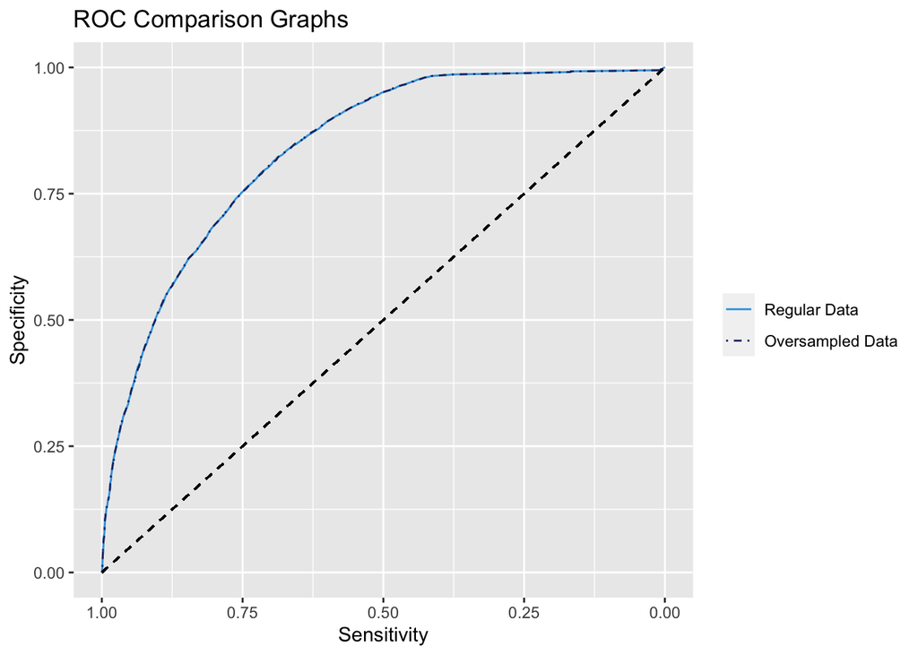

```r
ggroc(list("Regular Data" = regular_roc,
           "Oversampled Data" = sample_adjusted_roc), legacy.axis = TRUE, aes = c("linetype", "color")) +
  labs(title = "ROC Comparison Graphs",
       x = "Sensitivity",
       y = "Specificity") +
  scale_color_manual(values = c("Regular Data" = "#36A3E2", "Oversampled Data" =  "#213272")
    ,labels = c("Regular Data","Oversampled Data"))  +
  scale_linetype_manual(
                         values = c("solid",  "dotdash")) +
  theme(legend.title = element_blank()) +
  geom_segment(aes(x = 1, xend = 0, y = 0, yend = 1), color = "black", linetype = "dashed")
```

```r
auc(regular_roc)
```

```
## Area under the curve: 0.8398
```

```r
auc(sample_adjusted_roc)
```

```
## Area under the curve: 0.84
```

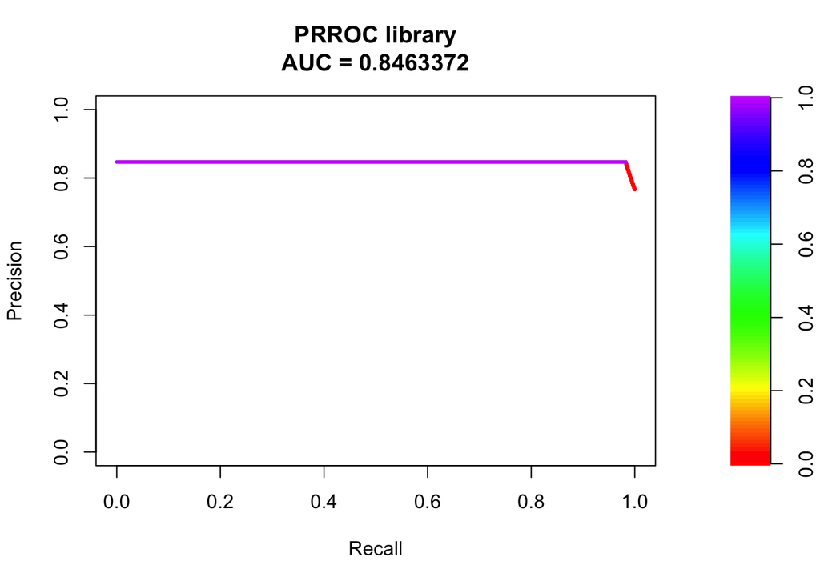

```r
regular <- data.frame(cbind(classification, test_set$user_type)) %>%
  rename(acutal = V2)

predictions <- regular$classification
actual <- regular$acutal

pr_curve = pr.curve(scores.class0 = predictions[actual == 1],  scores.class1 = predictions[actual == 0], curve = T)
plot(pr_curve, main = "PRROC library")
```

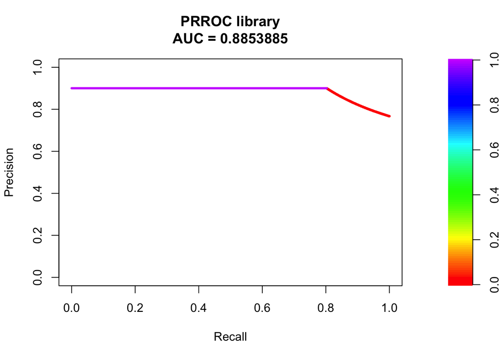

```r
adjusted <- data.frame(cbind(classification_adj, test_set$user_type)) %>%
  rename(acutal = V2)

predictions_adj <- adjusted$classification_adj
actual_adj <- adjusted$acutal

pr_curve = pr.curve(scores.class0 = predictions_adj[actual_adj == 1],  scores.class1 = predictions_adj[actual_adj == 0], curve = T)
plot(pr_curve, main = "PRROC library")
```

From the above curves we can see that the adjusted model has a slightly higher AOC related to precision/recall and sensitivity/specificity.